# PA1_template

Mark Odejobi

28 March 2017

## Loading and preprocessing the data

```r
activity <- read.csv("activity.csv")
activity$date <- as.Date(activity$date)
act_day <- group_by(activity,by=date)
sumStepsPerDay <- aggregate(steps ~ date, data=activity,
                            FUN="sum", na.exclude=T)
meanStepsPerInterval <- aggregate(steps ~ interval, data=activity,
                                  FUN="mean", na.exclude=T)
```

## Make the histogram of the total number of steps per day

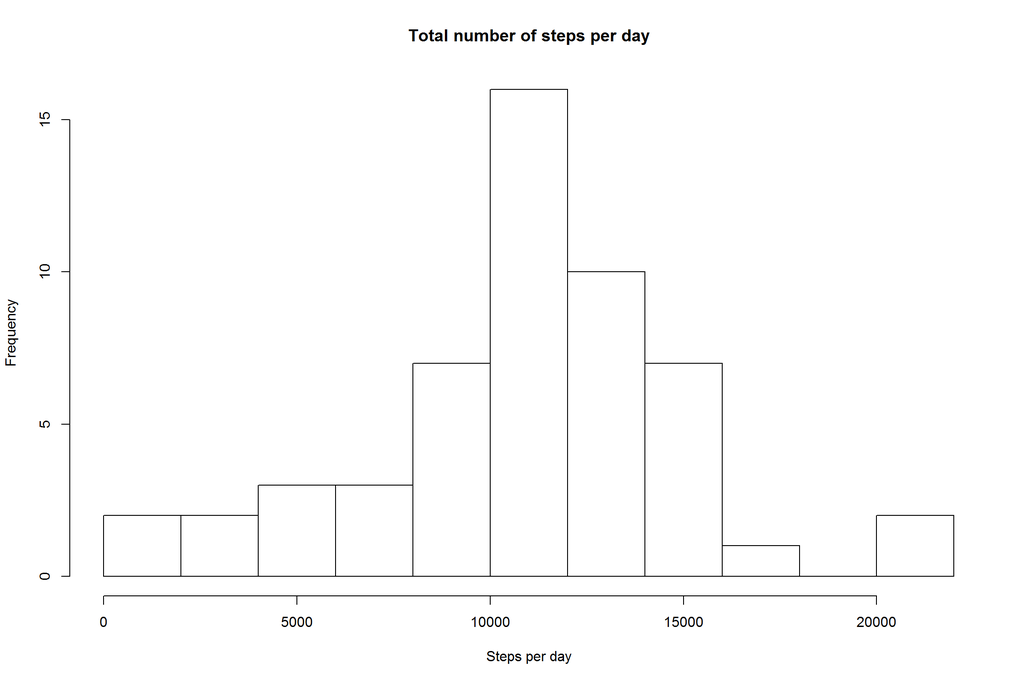

## What is mean total number of steps taken per day?

The mean and median steps are calculated as follows:

```r
mean(sumStepsPerDay$steps, na.rm=TRUE)
```

```
## [1] 10767.19
```

```r
median(sumStepsPerDay$steps, na.rm=TRUE)
```

```
## [1] 10766
```

## What is the average daily activity pattern?

Next, I will try to visualize the daily activity pattern

The below plot addresses the following items:

1. Make a time series plot (i.e. type = “l”) of the 5-minute interval (x-axis) and the average number of steps taken, averaged across all days (y-axis)
2. Which 5-minute interval, on average across all the days in the dataset, contains the maximum number of steps?

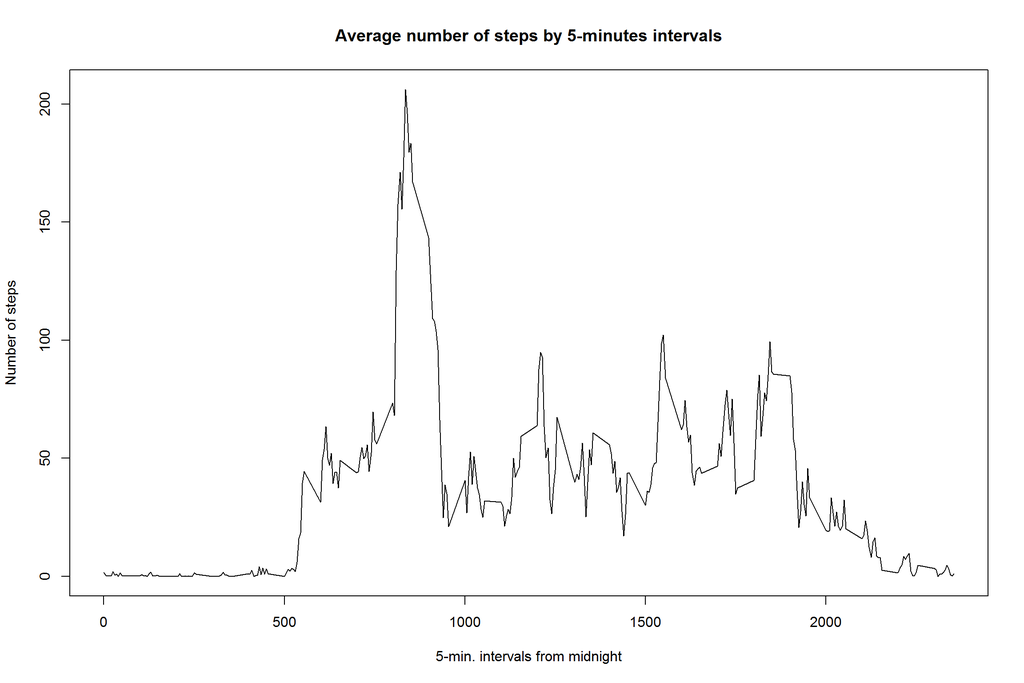

```r
plot(steps ~ interval, data=meanStepsPerInterval,
       type="l", grid=TRUE, ylab="Number of steps",
       xlab="5-min. intervals from midnight",
       main="Average number of steps by 5-minutes intervals")
```

```r
 max_steps <- meanStepsPerInterval[order(-meanStepsPerInterval$steps),]
 max_steps[1,1]
```

```
## [1] 835
```